# Opis podjętych problemów

1. Rozmiar zbioru testowego i treningowego
2. Rodzaj funkcji aktywacji
3. Liczba neuronów
4. Metoda uczenia

# Przegląd literatury

- https://media.statsoft.pl/_old_dnn/downloads/sieci%20neuronowe.pdf
- https://course.elementsofai.com/pl/5/2

## Biblioteki

```python
import pandas as pd
import numpy as np
from sklearn.model_selection import train_test_split
from sklearn.preprocessing import StandardScaler
import matplotlib.pyplot as plt
import seaborn as sns
```

Przygotowanie danych

```python
df = pd.read_csv("regresja/diamonds.csv")
```

### Opis danych

| Kolumna | Opis |
| --- | --- |
| **carat** | Masa diamentu wyrażona w karatach. |
| **cut** | Jakość szlifu diamentu (np. *Fair*, *Good*, *Very Good*, *Premium*, *Ideal*). |
| **color** | Kolor diamentu, oceniany w skali od **J** (najgorszy) do **D** (najlepszy). |
| **clarity** | Czystość diamentu, oceniana według następującej skali (od najgorszej do najlepszej): *I1*, *SI2*, *SI1*, *VS2*, *VS1*, *VVS2*, *VVS1*, *IF*. |
| **x** | Długość diamentu w milimetrach. |
| **y** | Szerokość diamentu w milimetrach. |
| **z** | Głębokość diamentu w milimetrach. |
| **depth** | Procentowa głębokość diamentu, obliczana jako `z / średnia(x, y)`. |
| **table** | Szerokość największego płaskiego obszaru (tzw. stołu) na górze diamentu, wyrażona w procentach. |
| **price** | Cena diamentu *(zmienna docelowa)*. |

Dane pochodzą ze strony https://www.kaggle.com/datasets/amirhosseinmirzaie/diamonds-price-dataset/

Przyjrzenie się pierwszym rekordom

```python
df.head()
```

|  | carat | cut | color | clarity | depth | table | price | x | y | z |
| --- | --- | --- | --- | --- | --- | --- | --- | --- | --- | --- |
| 0 | 0.23 | Ideal | E | SI2 | 61.5 | 55.0 | 326 | 3.95 | 3.98 | 2.43 |
| 1 | 0.21 | Premium | E | SI1 | 59.8 | 61.0 | 326 | 3.89 | 3.84 | 2.31 |
| 2 | 0.23 | Good | E | VS1 | 56.9 | 65.0 | 327 | 4.05 | 4.07 | 2.31 |
| 3 | 0.29 | Premium | I | VS2 | 62.4 | 58.0 | 334 | 4.20 | 4.23 | 2.63 |
| 4 | 0.31 | Good | J | SI2 | 63.3 | 58.0 | 335 | 4.34 | 4.35 | 2.75 |

Podstawowe statystyki opisowe

```python
df.describe()
```

|  | carat | depth | table | price | x | y | z |
| --- | --- | --- | --- | --- | --- | --- | --- |
| count | 50000.000000 | 50000.000000 | 50000.000000 | 50000.000000 | 50000.000000 | 50000.000000 | 50000.000000 |
| mean | 0.799444 | 61.753006 | 57.457830 | 3944.805440 | 5.734403 | 5.737956 | 3.541056 |
| std | 0.475173 | 1.431088 | 2.232092 | 3997.938105 | 1.123077 | 1.145579 | 0.707065 |
| min | 0.200000 | 43.000000 | 43.000000 | 326.000000 | 0.000000 | 0.000000 | 0.000000 |
| 25% | 0.400000 | 61.000000 | 56.000000 | 951.000000 | 4.710000 | 4.720000 | 2.910000 |
| 50% | 0.700000 | 61.800000 | 57.000000 | 2410.000000 | 5.700000 | 5.710000 | 3.530000 |
| 75% | 1.040000 | 62.500000 | 59.000000 | 5351.000000 | 6.540000 | 6.540000 | 4.040000 |
| max | 5.010000 | 79.000000 | 95.000000 | 18823.000000 | 10.740000 | 58.900000 | 31.800000 |

Usuwanie duplikatów i zmiana nazw kolumn

```python
df = df.drop_duplicates()
df = df.rename(columns={'x': 'length_in_mm', 'y': 'width_in_mm', 'z': 'depth_in_mm'})
```

Mapowanie cech jakościowych na liczby

```python
df['cut'] = df['cut'].map({'Ideal': 4, 'Premium': 3, 'Very Good': 2, 'Good': 1, 'Fair': 0})
df['color'] = df['color'].map({'D': 6, 'E': 5, 'F': 4, 'G': 3, 'H': 2, 'I': 1, 'J': 0})
df['clarity'] = df['clarity'].map({'IF': 7, 'VVS1': 6, 'VVS2': 5, 'VS1': 4, 'VS2': 3, 'SI1': 2, 'SI2': 1, 'I1': 0})
```

Macierz korelacji

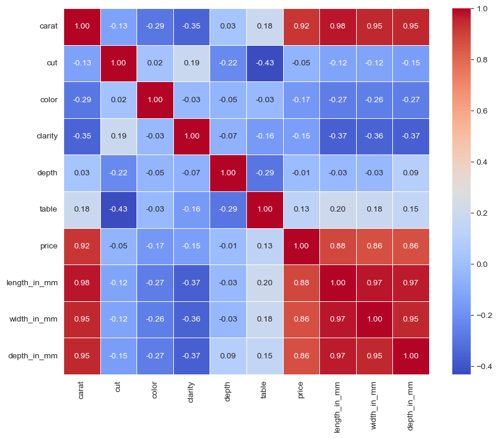

```python
corr = df.corr(numeric_only=True)
plt.figure(figsize=(10, 8))
sns.heatmap(corr, annot=True, cmap='coolwarm', fmt=".2f", square=True, linewidths=0.5)
plt.show()
```

Wykres rozkładu cen diamentów

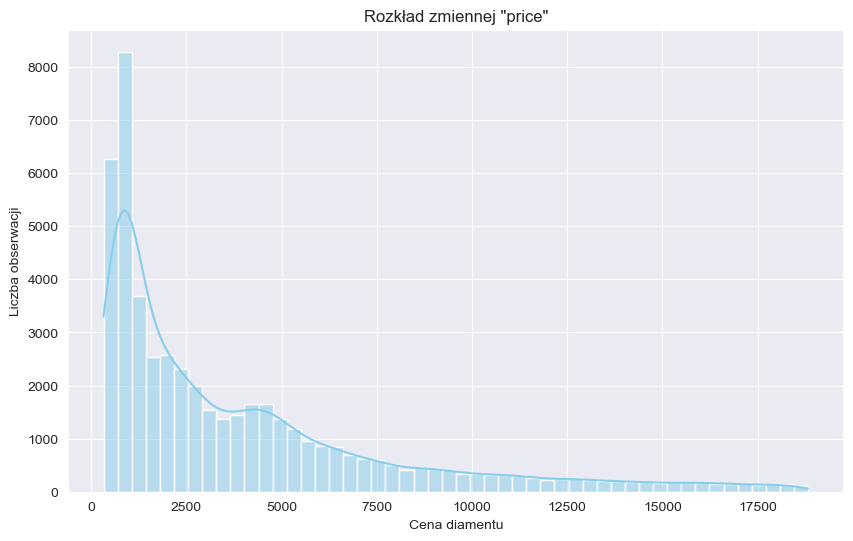

```python
plt.figure(figsize=(10, 6))
sns.histplot(df['price'], kde=True, bins=50, color='skyblue')
plt.title('Rozkład zmiennej "price"')
plt.xlabel('Cena diamentu')
plt.ylabel('Liczba obserwacji')
plt.show()
```

Podział na X i y

```python
X = df.drop(columns='price').values
y = df['price'].values.reshape(-1, 1)
```

Skalowanie X i y

```python
scaler_X = StandardScaler()
scaler_y = StandardScaler()

X_scaled = scaler_X.fit_transform(X)
y_scaled = scaler_y.fit_transform(y)
```

Podział na zbiór treningowy i testowy

```python
X_train, X_test, y_train, y_test = train_test_split(X_scaled, y_scaled, test_size=0.2, random_state=42)
```

# Tworzenie sieci neuronowej

```python
class NeuralNetwork:
    def __init__(self, input_size, hidden_size, output_size, activation='relu'):
        self.W1 = np.random.randn(input_size, hidden_size) * np.sqrt(2. / input_size)
        self.b1 = np.zeros((1, hidden_size))
        self.W2 = np.random.randn(hidden_size, output_size) * np.sqrt(2. / hidden_size)
        self.b2 = np.zeros((1, output_size))
        self.activation_name = activation.lower()

    def relu(self, z): return np.maximum(0, z)
    def relu_derivative(self, z): return (z > 0).astype(float)

    def sigmoid(self, z): return 1 / (1 + np.exp(-z))
    def sigmoid_derivative(self, z): a = self.sigmoid(z); return a * (1 - a)

    def tanh(self, z): return np.tanh(z)
    def tanh_derivative(self, z): return 1 - np.tanh(z) ** 2

    def linear(self, z): return z
    def linear_derivative(self, z): return np.ones_like(z)

    def activate(self, z):
        return {
            'relu': self.relu,
            'sigmoid': self.sigmoid,
            'tanh': self.tanh,
            'linear': self.linear
        }.get(self.activation_name, self.relu)(z)

    def activate_derivative(self, z):
        return {
            'relu': self.relu_derivative,
            'sigmoid': self.sigmoid_derivative,
            'tanh': self.tanh_derivative,
            'linear': self.linear_derivative
        }.get(self.activation_name, self.relu_derivative)(z)

    def forward(self, X):
        self.Z1 = X @ self.W1 + self.b1
        self.A1 = self.activate(self.Z1)
        self.Z2 = self.A1 @ self.W2 + self.b2
        return self.Z2

    def backward(self, X, y, output, learning_rate=0.005):
        m = X.shape[0]
        dZ2 = output - y
        dW2 = self.A1.T @ dZ2 / m
        db2 = np.sum(dZ2, axis=0, keepdims=True) / m
        dZ1 = dZ2 @ self.W2.T * self.activate_derivative(self.Z1)
        dW1 = X.T @ dZ1 / m
        db1 = np.sum(dZ1, axis=0, keepdims=True) / m

        self.W1 -= learning_rate * dW1
        self.b1 -= learning_rate * db1
        self.W2 -= learning_rate * dW2
        self.b2 -= learning_rate * db2

    def train(self, X, y, epochs=1000, learning_rate=0.005):
        for epoch in range(epochs):
            output = self.forward(X)
            loss = np.mean((output - y)**2)
            self.backward(X, y, output, learning_rate)
            if epoch % 100 == 0:
                print(f"Epoch {epoch}, Loss: {loss:.5f}")


    def predict(self, X):
        return self.forward(X)

model = NeuralNetwork(input_size=X_train.shape[1], hidden_size=64, output_size=1)
model.train(X_train, y_train, epochs=1000, learning_rate=0.05)

def create_model(activation='relu'):
    return NeuralNetwork(
        input_size=X_train.shape[1],
        hidden_size=64,
        output_size=1,
        activation=activation
    )
```

```
Epoch 0, Loss: 1.28391
Epoch 100, Loss: 0.06599
Epoch 200, Loss: 0.05673
Epoch 300, Loss: 0.05333
Epoch 400, Loss: 0.05135
Epoch 500, Loss: 0.04998
Epoch 600, Loss: 0.04896
Epoch 700, Loss: 0.04816
Epoch 800, Loss: 0.04750
Epoch 900, Loss: 0.04695
```

```python
y_pred_scaled = model.predict(X_test)

y_pred = scaler_y.inverse_transform(y_pred_scaled)
y_true = scaler_y.inverse_transform(y_test)


def train_batch(network, X, y, epochs=1000, learning_rate=0.01):
    for epoch in range(epochs):
        output = network.forward(X)
        loss = np.mean((output - y)**2)
        network.backward(X, y, output, learning_rate)
        if epoch % 100 == 0:
            print(f"[Batch] Epoch {epoch}, Loss: {loss:.5f}")

def train_rmsprop(network, X, y, epochs=1000, learning_rate=0.001, beta=0.9, epsilon=1e-8):
    cache_W1 = np.zeros_like(network.W1)
    cache_b1 = np.zeros_like(network.b1)
    cache_W2 = np.zeros_like(network.W2)
    cache_b2 = np.zeros_like(network.b2)

    for epoch in range(1, epochs + 1):
        output = network.forward(X)
        m = X.shape[0]

        dZ2 = output - y
        dW2 = network.A1.T @ dZ2 / m
        db2 = np.sum(dZ2, axis=0, keepdims=True) / m
        dZ1 = dZ2 @ network.W2.T * network.activate_derivative(network.Z1)
        dW1 = X.T @ dZ1 / m
        db1 = np.sum(dZ1, axis=0, keepdims=True) / m

        cache_W1 = beta * cache_W1 + (1 - beta) * dW1**2
        cache_b1 = beta * cache_b1 + (1 - beta) * db1**2
        cache_W2 = beta * cache_W2 + (1 - beta) * dW2**2
        cache_b2 = beta * cache_b2 + (1 - beta) * db2**2

        network.W1 -= learning_rate * dW1 / (np.sqrt(cache_W1) + epsilon)
        network.b1 -= learning_rate * db1 / (np.sqrt(cache_b1) + epsilon)
        network.W2 -= learning_rate * dW2 / (np.sqrt(cache_W2) + epsilon)
        network.b2 -= learning_rate * db2 / (np.sqrt(cache_b2) + epsilon)

        if epoch % 100 == 0:
            loss = np.mean((output - y) ** 2)
            print(f"[RMSProp] Epoch {epoch}, Loss: {loss:.5f}")

def train_minibatch(network, X, y, epochs=1000, learning_rate=0.001, batch_size=32):
    for epoch in range(epochs):
        indices = np.random.permutation(X.shape[0])
        X_shuffled = X[indices]
        y_shuffled = y[indices]
        for i in range(0, X.shape[0], batch_size):
            xb = X_shuffled[i:i+batch_size]
            yb = y_shuffled[i:i+batch_size]
            output = network.forward(xb)
            network.backward(xb, yb, output, learning_rate)
        if epoch % 100 == 0:
            loss = np.mean((network.forward(X) - y)**2)
            print(f"[MiniBatch] Epoch {epoch}, Loss: {loss:.5f}")

def train_adam(network, X, y, epochs=1000, learning_rate=0.001, beta1=0.9, beta2=0.999, epsilon=1e-8):
    mW1 = np.zeros_like(network.W1)
    mb1 = np.zeros_like(network.b1)
    mW2 = np.zeros_like(network.W2)
    mb2 = np.zeros_like(network.b2)

    vW1 = np.zeros_like(network.W1)
    vb1 = np.zeros_like(network.b1)
    vW2 = np.zeros_like(network.W2)
    vb2 = np.zeros_like(network.b2)

    for epoch in range(1, epochs + 1):
        output = network.forward(X)

        m = X.shape[0]
        dZ2 = output - y
        dW2 = network.A1.T @ dZ2 / m
        db2 = np.sum(dZ2, axis=0, keepdims=True) / m
        dZ1 = dZ2 @ network.W2.T * network.activate_derivative(network.Z1)
        dW1 = X.T @ dZ1 / m
        db1 = np.sum(dZ1, axis=0, keepdims=True) / m

        mW1 = beta1 * mW1 + (1 - beta1) * dW1
        mb1 = beta1 * mb1 + (1 - beta1) * db1
        mW2 = beta1 * mW2 + (1 - beta1) * dW2
        mb2 = beta1 * mb2 + (1 - beta1) * db2

        vW1 = beta2 * vW1 + (1 - beta2) * (dW1 ** 2)
        vb1 = beta2 * vb1 + (1 - beta2) * (db1 ** 2)
        vW2 = beta2 * vW2 + (1 - beta2) * (dW2 ** 2)
        vb2 = beta2 * vb2 + (1 - beta2) * (db2 ** 2)

        mW1_hat = mW1 / (1 - beta1 ** epoch)
        mb1_hat = mb1 / (1 - beta1 ** epoch)
        mW2_hat = mW2 / (1 - beta1 ** epoch)
        mb2_hat = mb2 / (1 - beta1 ** epoch)

        vW1_hat = vW1 / (1 - beta2 ** epoch)
        vb1_hat = vb1 / (1 - beta2 ** epoch)
        vW2_hat = vW2 / (1 - beta2 ** epoch)
        vb2_hat = vb2 / (1 - beta2 ** epoch)

        network.W1 -= learning_rate * mW1_hat / (np.sqrt(vW1_hat) + epsilon)
        network.b1 -= learning_rate * mb1_hat / (np.sqrt(vb1_hat) + epsilon)
        network.W2 -= learning_rate * mW2_hat / (np.sqrt(vW2_hat) + epsilon)
        network.b2 -= learning_rate * mb2_hat / (np.sqrt(vb2_hat) + epsilon)

        if epoch % 100 == 0:
            loss = np.mean((output - y) ** 2)
            print(f"[Adam] Epoch {epoch}, Loss: {loss:.5f}")



print("\nPrzykładowe przewidywania (prawdziwa cena vs przewidziana):")
for i in range(5):
    print(f"Rzeczywista: {y_true[i][0]:,.2f} \t|\tPrzewidziana: {y_pred[i][0]:,.2f} ")
```

```
Przykładowe przewidywania (prawdziwa cena vs przewidziana):
Rzeczywista: 9,038.00 	|	Przewidziana: 9,520.53
Rzeczywista: 7,371.00 	|	Przewidziana: 7,507.67
Rzeczywista: 680.00 	|	Przewidziana: 597.39
Rzeczywista: 701.00 	|	Przewidziana: 1,377.56
Rzeczywista: 2,875.00 	|	Przewidziana: 4,079.13
```

# Badania

## Analiza wpływu rozmiaru zbioru testowego i treningowego na działanie sieci

Pobranie zapisanych wartości z excela `podzial_dane_test_trening.xlsx`.  
Plik z kodem `podzial_dane_test_trening.py`

### Opis problemu i podjętych kroków

W celu analizy działania stworzonej sieci neuronowej, zdecydowałem się zbadać wpływ rozmiaru zbioru treningowego i testowego na skuteczność modelu. Sieć była trenowana wielokrotnie, przy różnych podziałach danych, a następnie oceniana na podstawie miar błędu: MAE, RMSE oraz współczynnika dopasowania R².

Analiza została przeprowadza w pliku `podzial_dane_test_trening.py`. Następnie rezultaty zapisane w pliku `podzial_dane_test_trening.xlsx` i odczytane w Jupyter. Zostały zwizualizowane i przeanalizowane. Na samym końcu wyciągnąte wnioski.

```python
plik = 'regresja/podzial_dane_test_trening.xlsx'
xls = pd.ExcelFile(plik)
train_test_df = xls.parse()
train_test_df=train_test_df.round(4)
```

```python
train_test_df
```

|  | Test Size | Train Size | Train MAE | Train RMSE | Train R2 | Test MAE | Test RMSE | Test R2 |
| --- | --- | --- | --- | --- | --- | --- | --- | --- |
| 0 | 0.1 | 0.9 | 652.2899 | 982.0643 | 0.9397 | 659.5460 | 1037.4186 | 0.9308 |
| 1 | 0.2 | 0.8 | 646.7825 | 994.2840 | 0.9381 | 647.4420 | 1019.9288 | 0.9339 |
| 2 | 0.3 | 0.7 | 633.4890 | 970.1087 | 0.9412 | 638.0341 | 1060.2404 | 0.9289 |
| 3 | 0.4 | 0.6 | 642.0883 | 980.3112 | 0.9399 | 645.5427 | 1029.6400 | 0.9330 |

```python
train_test_df.describe()
```

|  | Test Size | Train Size | Train MAE | Train RMSE | Train R2 | Test MAE | Test RMSE | Test R2 |
| --- | --- | --- | --- | --- | --- | --- | --- | --- |
| count | 4.000000 | 4.000000 | 4.000000 | 4.000000 | 4.000000 | 4.000000 | 4.000000 | 4.000000 |
| mean | 0.250000 | 0.750000 | 643.662425 | 981.692050 | 0.939725 | 647.641200 | 1036.806950 | 0.931650 |
| std | 0.129099 | 0.129099 | 7.961253 | 9.912560 | 0.001271 | 8.915605 | 17.182722 | 0.002249 |
| min | 0.100000 | 0.600000 | 633.489000 | 970.108700 | 0.938100 | 638.034100 | 1019.928800 | 0.928900 |
| 25% | 0.175000 | 0.675000 | 639.938475 | 977.760575 | 0.939300 | 643.665550 | 1027.212200 | 0.930325 |
| 50% | 0.250000 | 0.750000 | 644.435400 | 981.187750 | 0.939800 | 646.492350 | 1033.529300 | 0.931900 |
| 75% | 0.325000 | 0.825000 | 648.159350 | 985.119225 | 0.940225 | 650.468000 | 1043.124050 | 0.933225 |
| max | 0.400000 | 0.900000 | 652.289900 | 994.284000 | 0.941200 | 659.546000 | 1060.240400 | 0.933900 |

Wykres R² vs Train Size

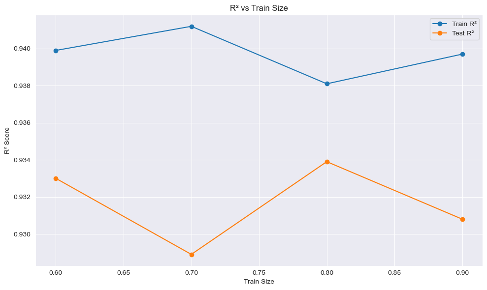

```python
plt.figure(figsize=(10, 6))
plt.plot(train_test_df["Train Size"], train_test_df["Train R2"], marker='o', label='Train R²')
plt.plot(train_test_df["Train Size"], train_test_df["Test R2"], marker='o', label='Test R²')
plt.title('R² vs Train Size')
plt.xlabel('Train Size')
plt.ylabel('R² Score')
plt.legend()
plt.grid(True)
plt.tight_layout()
plt.show()
```

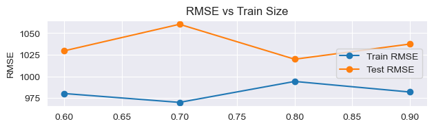

```python
plt.subplot(3, 1, 2)
plt.plot(train_test_df["Train Size"], train_test_df["Train RMSE"], marker='o', label='Train RMSE')
plt.plot(train_test_df["Train Size"], train_test_df["Test RMSE"], marker='o', label='Test RMSE')
plt.title('RMSE vs Train Size')
plt.ylabel('RMSE')
plt.grid(True)
plt.legend()
plt.tight_layout()
plt.show()
```

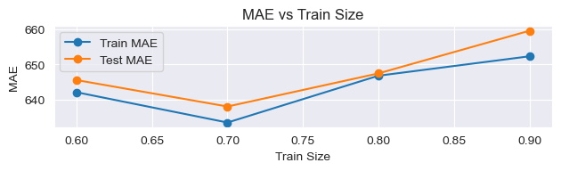

```python
plt.subplot(3, 1, 3)
plt.plot(train_test_df["Train Size"], train_test_df["Train MAE"], marker='o', label='Train MAE')
plt.plot(train_test_df["Train Size"], train_test_df["Test MAE"], marker='o', label='Test MAE')
plt.title('MAE vs Train Size')
plt.xlabel('Train Size')
plt.ylabel('MAE')
plt.grid(True)
plt.legend()
plt.tight_layout()
plt.show()
```

```python
best_index = train_test_df["Test R2"].idxmax()
best_split = train_test_df.loc[best_index]
print("\nNajlepszy podział danych:")
print(f"Test Size: {best_split['Test Size']}")
print(f"Train Size: {best_split['Train Size']}")
print(f"Train R²: {best_split['Train R2']:.4f}")
print(f"Test R²: {best_split['Test R2']:.4f}")
print(f"\nTrain MAE:  {best_split['Train MAE']}")
print(f"Test MAE:   {best_split['Test MAE']}")
print(f"\nTrain RMSE: {best_split['Train RMSE']}")
print(f"Test RMSE:  {best_split['Test RMSE']}")
```

```
Najlepszy podział danych:
Test Size: 0.2
Train Size: 0.8
Train R²: 0.9381
Test R²: 0.9339

Train MAE:  646.7825
Test MAE:   647.442

Train RMSE: 994.284
Test RMSE:  1019.9288
```

Wnioski :

- Zwiększanie zbioru treningowego do 80% poprawia jakość generalizacji sieci (maksimum dla R2 na zbiorze testowym).
- Dalsze zwiększanie zbioru treningowego (do 90%) nie poprawia już wyników, a nawet lekko je pogarsza.
- Wartość R2 na zbiorze testowym jest bardzo zbliżona do wartości na zbiorze treningowym, co świadczy o braku nadmiernego dopasowania

# Analiza wpływu rodzaju funkcji aktywacji na działanie sieci

### Opis problemu

W celu analizy działania sieci neuronowej zdecydowałem się zbadać wpływ funkcji aktywacji na skuteczność modelu. Sieć była trenowana przy stałym podziale danych, a różne funkcje aktywacji wprowadzały nieliniowość, co pozwalało na modelowanie złożonych zależności. Ocena modelu odbywała się na podstawie miar błędu: MAE, RMSE oraz współczynnika dopasowania R²

Poniżej znajduje się wczytanie danych z pliku `porownanie_aktywacji.csv` a następnie ich analiza.

```python
df_funkcje_aktywacji= pd.read_csv('regresja/porownanie_aktywacji.csv')
df_funkcje_aktywacji.drop('MSE', axis=1, inplace=True)
df_funkcje_aktywacji
```

|  | Aktywacja | Zbiór | RMSE | MAE | R2 | MAPE (%) |
| --- | --- | --- | --- | --- | --- | --- |
| 0 | relu | Train | 1051.713986 | 696.409275 | 0.930860 | 33.781065 |
| 1 | relu | Test | 1205.615579 | 708.631928 | 0.904879 | 33.904453 |
| 2 | sigmoid | Train | 1637.488952 | 1177.773215 | 0.832778 | 59.518282 |
| 3 | sigmoid | Test | 1644.443360 | 1188.135607 | 0.827761 | 59.496719 |
| 4 | tanh | Train | 1567.436954 | 1132.156651 | 0.846196 | 63.080116 |
| 5 | tanh | Test | 1572.582794 | 1139.215849 | 0.841910 | 63.284782 |
| 6 | linear | Train | 1234.164299 | 832.775397 | 0.905049 | 46.261509 |
| 7 | linear | Test | 1289.878816 | 840.187403 | 0.894060 | 45.722004 |

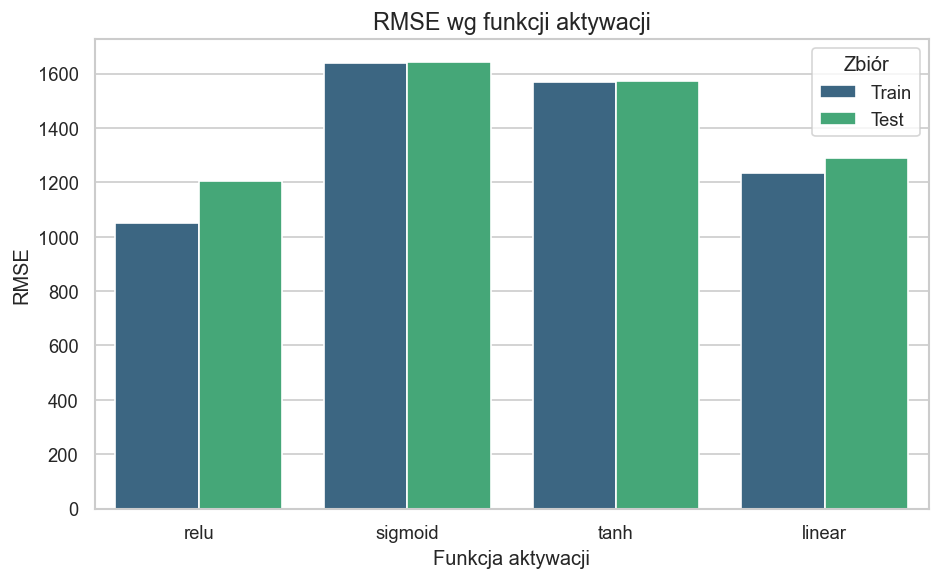

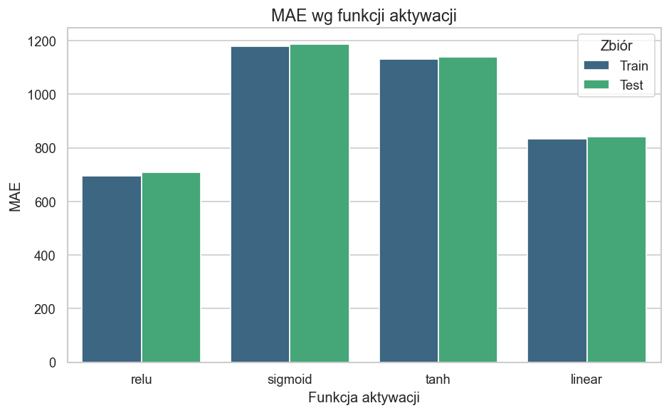

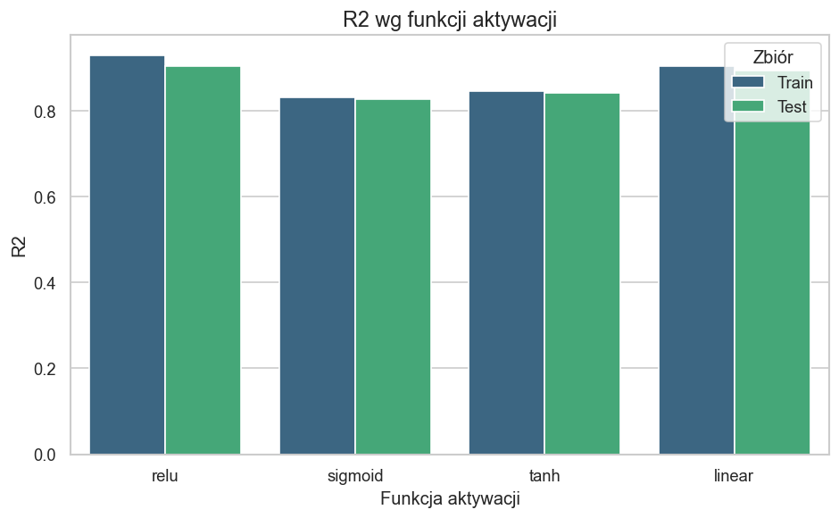

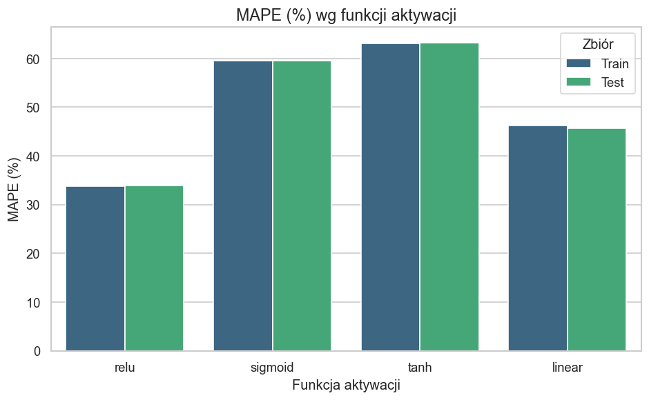

```python
sns.set_theme(style="whitegrid")
plt.rcParams['figure.dpi'] = 120

metrics = ['RMSE', 'MAE', 'R2', 'MAPE (%)']

for metric in metrics:
    plt.figure(figsize=(8, 5))
    sns.barplot(data=df_funkcje_aktywacji, x='Aktywacja', y=metric, hue='Zbiór', palette='viridis')
    plt.title(f'{metric} wg funkcji aktywacji', fontsize=14)
    plt.ylabel(metric)
    plt.xlabel('Funkcja aktywacji')
    plt.legend(title='Zbiór')
    plt.tight_layout()
    plt.show()
```

Wnioski :

- Funkcja aktywacji ReLU uzyskuje najniższe wartości błędów (RMSE, MAE, MAPE) zarówno na zbiorze treningowym, jak i testowym, co świadczy o jej najlepszej skuteczności predykcyjnej w tym zadaniu.
- Funkcje sigmoid i tanh wypadają zdecydowanie najgorzej – charakteryzują się najwyższymi wartościami błędów oraz najniższym współczynnikiem determinacji R², co oznacza, że model z tymi funkcjami gorzej dopasowuje się do danych i słabiej generalizuje.
- Różnice pomiędzy wynikami na zbiorze treningowym i testowym są niewielkie dla wszystkich funkcji aktywacji, co sugeruje brak wyraźnego przeuczenia (overfittingu) w modelach.
- Najlepszy kompromis pomiędzy niskimi błędami a wysoką wartością R² zapewnia funkcja ReLU, która powinna być preferowanym wyborem w tym przypadku.

# Wpływ liczby neuronów na sieć

Pobranie zapisanych wartości z excela (`porownanie_neuronow.csv`).  
Plik z kodem `liczba_neuron.py`

### Opis problemu

W celu analizy działania stworzonej sieci neuronowej, zdecydowałem się zbadać wpływ jak rozbudowa warstwy ukrytej wpływa na dokładność predykcji ceny diamentu.

```python
df_neurony= pd.read_csv('regresja/porownanie_neuronow.csv')
df_neurony.drop('MSE', axis=1, inplace=True)
df_neurony
```

|  | Neurony | Zbiór | RMSE | MAE | R2 | MAPE (%) |
| --- | --- | --- | --- | --- | --- | --- |
| 0 | 5 | Train | 1245.440421 | 817.902261 | 0.903006 | 42.547418 |
| 1 | 5 | Test | 1464.202588 | 835.548334 | 0.857250 | 43.067386 |
| 2 | 10 | Train | 1147.670165 | 711.256389 | 0.917828 | 33.322168 |
| 3 | 10 | Test | 1270.682918 | 725.956309 | 0.896105 | 33.531958 |
| 4 | 20 | Train | 1106.015954 | 705.332650 | 0.923519 | 32.654560 |
| 5 | 20 | Test | 1210.929315 | 718.812369 | 0.905357 | 32.989887 |
| 6 | 50 | Train | 954.070422 | 615.110426 | 0.943246 | 28.661399 |
| 7 | 50 | Test | 1132.602692 | 631.273383 | 0.917999 | 29.041923 |

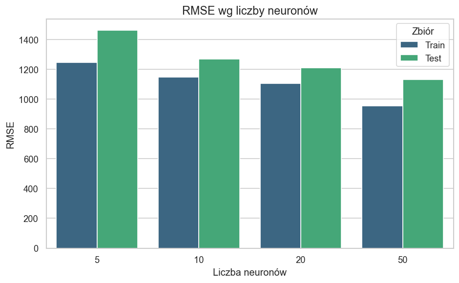

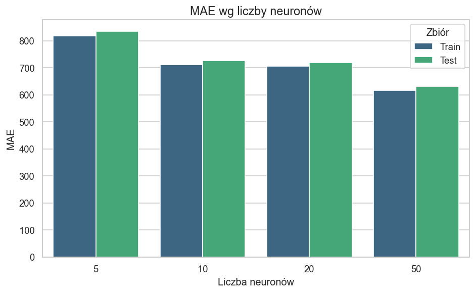

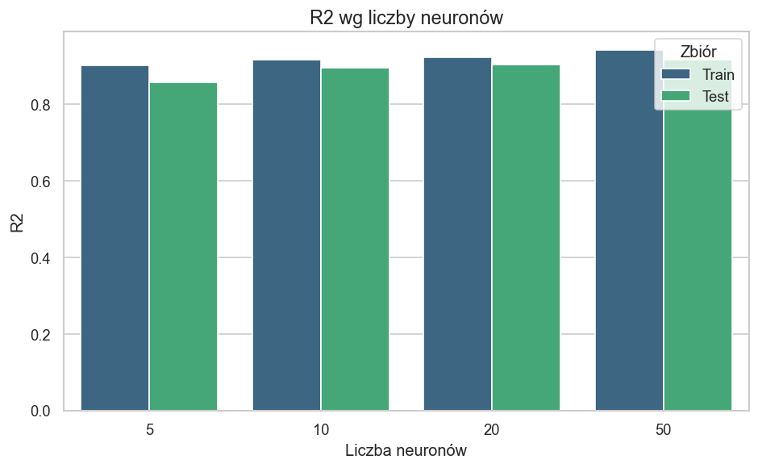

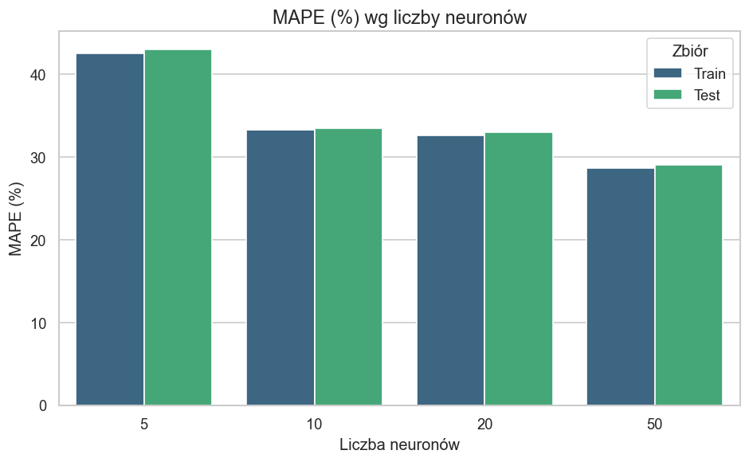

```python
sns.set_theme(style="whitegrid")
plt.rcParams['figure.dpi'] = 120

metrics = ['RMSE', 'MAE', 'R2', 'MAPE (%)']

for metric in metrics:
    plt.figure(figsize=(8, 5))
    sns.barplot(data=df_neurony, x='Neurony', y=metric, hue='Zbiór', palette='viridis')
    plt.title(f'{metric} wg liczby neuronów', fontsize=14)
    plt.ylabel(metric)
    plt.xlabel('Liczba neuronów')
    plt.legend(title='Zbiór')
    plt.tight_layout()
    plt.show()
```

# Wpływ metody uczenia na sieć

Pobranie zapisanych wartości z excela (`'analiza_metod.csv'`).  
Plik z kodem `metody.py`

### Opis problemu

W celu analizy działania stworzonej sieci neuronowej, zdecydowałem się zbadać wpływ zastosowanej metody uczenia na skuteczność modelu. Sieć była trenowana wielokrotnie z wykorzystaniem różnych algorytmów optymalizacji: batch gradient descent, mini-batch gradient descent, RMSProp oraz Adam. Następnie modele były oceniane na podstawie miar błędu: MAE, RMSE oraz współczynnika dopasowania R².

```python
df_metody= pd.read_csv('regresja/analiza_metod.csv')
df_metody.drop('MSE', axis=1, inplace=True)
df_metody['Method'] = df_metody['Method'].replace({
    'Batch Gradient Descent': 'Batch GD',
    'Mini-Batch Gradient Descent': 'Mini-Batch GD',
    'Adam Optimizer': 'Adam Optimizer',
    'RMSProp': 'RMSProp'
})
df_metody
```

|  | Method | Set | RMSE | MAE | MAPE (%) | R² |
| --- | --- | --- | --- | --- | --- | --- |
| 0 | Batch GD | Train | 1694.136236 | 1221.226375 | 69.279923 | 0.818701 |
| 1 | Batch GD | Test | 1957.237572 | 1243.414298 | 69.762946 | 0.742588 |
| 2 | Mini-Batch GD | Train | 784.285163 | 472.869526 | 19.967467 | 0.961655 |
| 3 | Mini-Batch GD | Test | 834.518224 | 485.347284 | 20.188393 | 0.955635 |
| 4 | Adam Optimizer | Train | 908.238862 | 596.266904 | 28.504253 | 0.948374 |
| 5 | Adam Optimizer | Test | 998.758097 | 606.325444 | 28.534656 | 0.935892 |
| 6 | RMSProp | Train | 792.686787 | 486.474632 | 20.580462 | 0.960791 |
| 7 | RMSProp | Test | 840.164292 | 500.086490 | 20.947885 | 0.955032 |

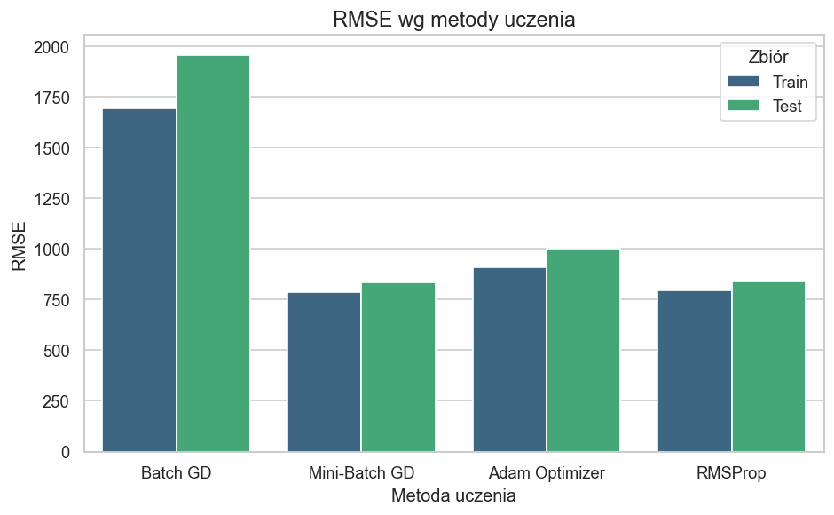

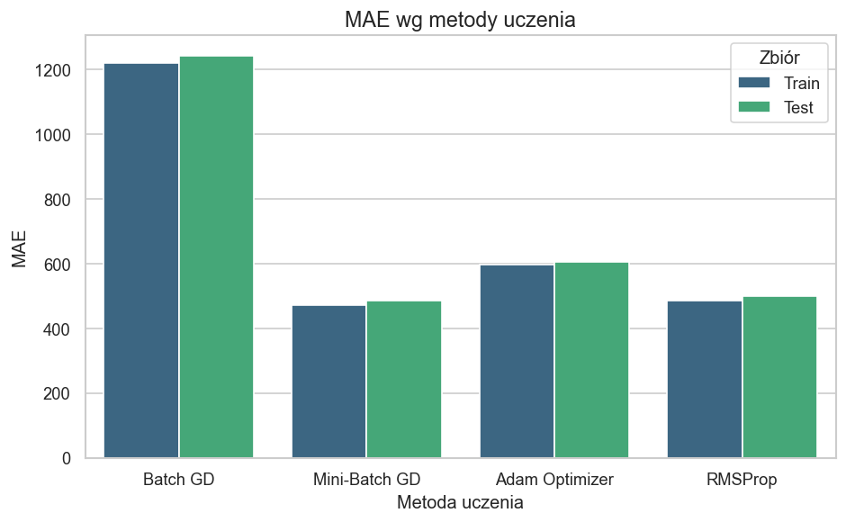

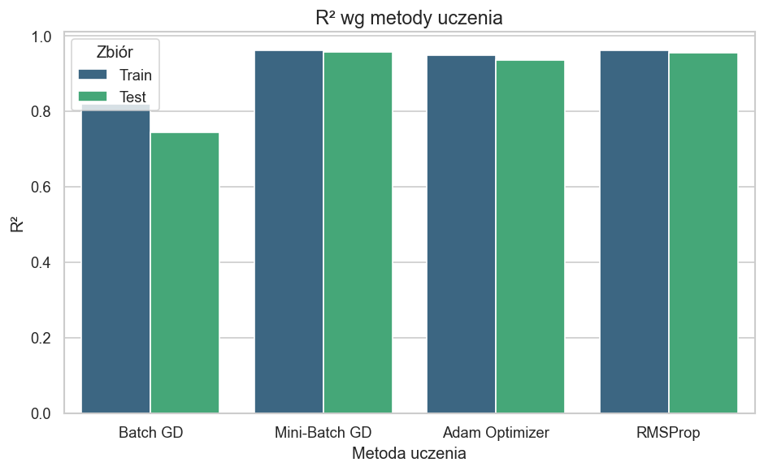

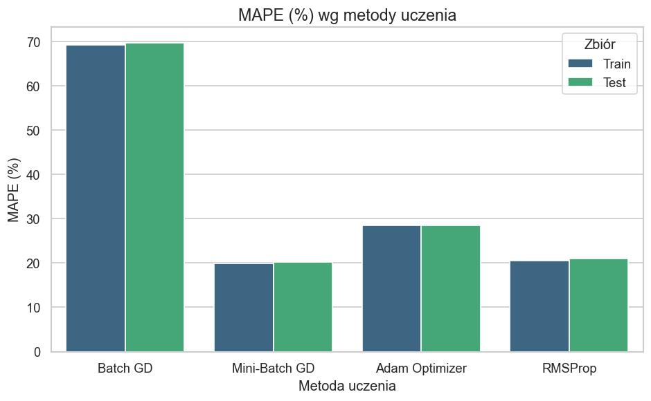

```python
sns.set_theme(style="whitegrid")
plt.rcParams['figure.dpi'] = 120

metrics = ['RMSE', 'MAE', 'R²', 'MAPE (%)']

for metric in metrics:
    plt.figure(figsize=(8, 5))
    sns.barplot(data=df_metody, x='Method', y=metric, hue='Set', palette='viridis')
    plt.title(f'{metric} wg metody uczenia', fontsize=14)
    plt.ylabel(metric)
    plt.xlabel('Metoda uczenia')
    plt.legend(title='Zbiór')
    plt.tight_layout()
    plt.show()
```

Wnioski:

- Metoda Batch GD osiąga najwyższe wartości błędu RMSE zarówno dla zbioru treningowego, jak i testowego, co wskazuje na najsłabszą skuteczność predykcyjną
- Podobnie jak w RMSE, Batch GD osiąga najwyższe wartości MAE, co potwierdza jego niską skuteczność.
- Batch GD ma również najwyższy błąd procentowy MAPE, co potwierdza, że metoda ta znacząco odstaje od pozostałych pod względem jakości predykcji.
- Metody Mini-Batch GD, Adam Optimizer i RMSProp osiągają bardzo wysokie wartości R2 zarówno dla zbioru treningowego, jak i testowego, co świadczy o ich dużej skuteczności i dobrej generalizacji modelu.
- Metoda Batch GD wypada najgorzej w każdym przebadanym przypadku
- Dominacja Mini-Batch GD we wszystkich testach sugeruje, że jest to najbardziej uniwersalna i skuteczna metoda uczenia spośród porównywanych.